# segRDA: An R package for performing piecewise redundancy analysis

## 2.2 Pooled SMW with randomization tests

The function `PoolSMW` creates a pooled SMW dissimilarity profile by averaging together dissimilarities profiles from several different window sizes (for each window midpoint location). The window sizes to be analysed are specified as a vector in the argument `windows`. All windows sizes must be even. Because results of SMW are scale-dependent, dissimilarity values for each window are transformed into standardized variables (Z scores). Note that the running time of this analysis will be proportional to the number of randomizations (`n.rand`) times the number of window sizes analyzed (`length(windows`). The progress of the analysis while running is automatically displayed.

```r
pooled.sim<-PoolSMW(y=y.ord,windows=c(10,20,30,40,50), n.rand=10)
```

```
## Progress 20 %
```

```
## Progress 40 %
```

```
## Progress 60 %
```

```
## Progress 80 %
```

```
## Progress 100 %
```

This function returns an smw object of class `pool` similar to the output from `SMW.test`.

```r
ls(pooled.sim) ## List of objects in SMW.test output
```

```
## [1] "DP"            "params"        "result.pooled"
```

```r
head(pooled.sim$DP) ## Dissimilarity profile table
```

```
##   positions SiteID   AverageZ sig:AverageZ
## 1         5     29 -2.8144777        FALSE
## 2         6     39 -2.3641426        FALSE
## 3         7     88 -2.3854054        FALSE
## 4         8     69 -2.7293468        FALSE
## 5         9     72 -2.6021958        FALSE
## 6        10     18 -0.5843103        FALSE
```

The object returned by `PoolSMW` can also be used by both `Dprofile` and `Dprofile2`. The latter drawns together the profiles obtained from the different sizes of windows. When `count='TRUE'`, the function uses `BPlocation` with defaults parameters to count the number of breakpoints. `BPlocation` arguments can be passed to `Dprofile2`.

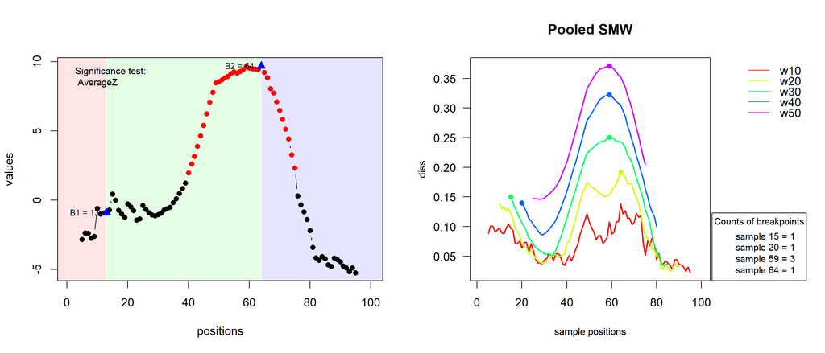

```r
par(mfrow=c(1,2),cex=1.2)
Dprofile(pooled.sim, BP=BP1, bg=.1)
Dprofile2(pooled.sim)
```

# 3 Piecewise redundancy analysis (pwRDA)

Once the breakpoints have been defined and their significance tested, the pwRDA can be implemented. It is done with the function `pwRDA`. The function has three arguments: `x` explanatory variables, `y` response variables and `cps` the positions of the breakpoints. The function displays a message with the main result of the analysis:

```r
pw.sim<-pwRDA(x.ord=x.ord,y.ord=y.ord, BPs=BP1, progress=F)
```

```
##
##      pwRDA analysis
##  ------------------------
##  ** Summary statistics **
##  ------------------------
##      Statistic      P.value
## FULL 0.6669938 0.0010000000
## PW   0.8137350 0.0000015387
## F    1.2933436 0.2383671968
##  ------------------------
##
```

The function returns an invisible list with following descriptors: - `$summ`: a vector containing the summarized statistics. - `$rda.0` and `$rda.pw`: the respectives `cca` objects from the full and “pw”" RDA models. These objects can be used in all functions that applies to `cca.object`. More details are in `help(cca.object){vegan}`.

```r
head(pw.sim$summ)
```

```
##      Statistic      P.value
## FULL 0.6669938 0.0010000000
## PW   0.8137350 0.0000015387
## F    1.2933436 0.2383671968
```

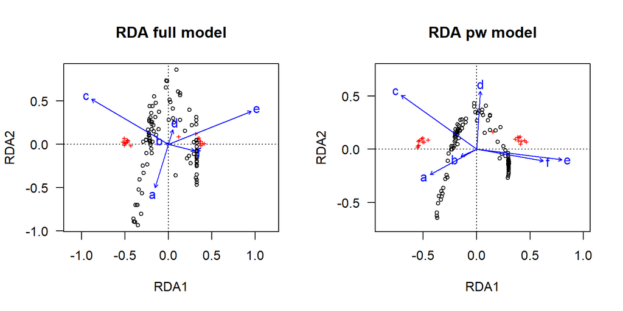

```r
par(mfrow=c(1,2))
plot(pw.sim$rda.0, main="RDA full model", las=1)
plot(pw.sim$rda.pw, main="RDA pw model", las=1)
```